# PracMachLearnProject

jhn316

March 15, 2016

# Overview of the task

Accelerometers are attached onto 6 different study participants doing weight-lifting exercises on their on the belt, forearm, arm, and dumbell. The weight lifing exercises are performed in 5 different ways categorized as classes A,B,C,D and E. The goal is to see if we can bulid a model based on the accelerometer data that will tell us in which way (i.e. A,B,C,D or E) the exercise is being performed.

### Load the required packages

```r
library(caret)
library(Amelia)
```

### Load the data into R accounting for missing values

```r
dat.train = read.csv("pml-training.csv", na.strings=c("NA","#DIV/0!",""))
dat.test = read.csv("pml-testing.csv", na.strings=c("NA","#DIV/0!",""))
```

## Preparing the data

Prior to applying any machine learning algorithm, the raw data can be cleaned up by removing predictors with large amounts of missng values, non-zero variances, as well as removing those predictors which obviously have no predictive power in this instance such as time stamps.

### Remove the near zero variance columns data

```r
novar <- nearZeroVar(dat.train, saveMetrics=TRUE)
dat.train <- dat.train[,novar$nzv==FALSE]
```

### Remove the columns with missing values

```r
NAcols <- sapply(dat.train, function(x)sum(is.na(x)))==0
dat.train <- dat.train[,NAcols]
```

### Visualize if there are missing values

The missmap function is a good way of visualizing missing values. In the figures below, missing values would show up in yellow and present values in black. As can be seen, there are no more missing values in the set of predictors which we are left with after cleaning up.

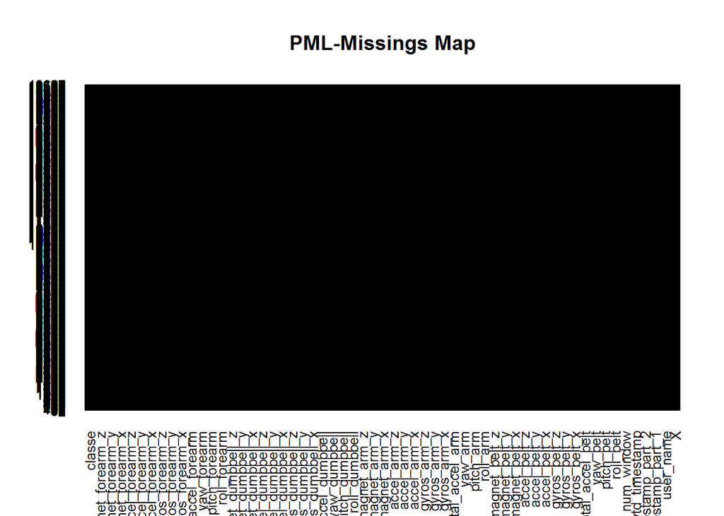

```r
missmap(dat.train, main="PML-Missings Map",
        col=c("yellow", "black"), legend=FALSE)
```

We then manually remove the columns which are obviously not useful in predicting, namely the first 5 columns.

```r
dat.train <- dat.train[,-(1:5)]
```

## Create a training and a test set

We partition the pml-training data into a training and test set with a 60%:40% split.

```r
inTrain <- createDataPartition(dat.train$classe, p=0.6, list=FALSE)
train.set <- dat.train[inTrain, ]
test.set <- dat.train[-inTrain, ]
```

## Model building

We build a model on the train.set using 5 fold cross-validation. and then we run a random forest algorithm.

```r
crossvalid <- trainControl(method="cv", number=5, verboseIter=FALSE)
model1 <- train(classe ~ ., data=train.set, method="rf", trControl=crossvalid)
```

We then explore the final model to see the results.

```r
model1$finalModel
```

```
##
## Call:
##  randomForest(x = x, y = y, mtry = param$mtry)
##                Type of random forest: classification
##                      Number of trees: 500
## No. of variables tried at each split: 27
##
##         OOB estimate of  error rate: 0.26%
## Confusion matrix:
##      A    B    C    D    E class.error
## A 3348    0    0    0    0 0.000000000
## B    4 2270    5    0    0 0.003949100
## C    0    5 2049    0    0 0.002434275
## D    0    0   11 1919    0 0.005699482
## E    0    1    0    5 2159 0.002771363
```

This model has pretty good classification error rates.

## Model evaluation- test set error

Using the model we have trained abouve, we predict on the test data to estimate the out of sample error.

```r
test.pred <- predict(model1, newdata=test.set)
confusionMatrix(test.set$classe, test.pred)
```

```
## Confusion Matrix and Statistics
##
##           Reference
## Prediction    A    B    C    D    E
##          A 2231    0    0    0    1
##          B    6 1509    2    1    0
##          C    0    1 1367    0    0
##          D    0    0    8 1277    1
##          E    0    0    0    5 1437
##
## Overall Statistics
##
##                Accuracy : 0.9968
##                  95% CI : (0.9953, 0.9979)
##     No Information Rate : 0.2851
##     P-Value [Acc > NIR] : < 2.2e-16
##
##                   Kappa : 0.996
##  Mcnemar's Test P-Value : NA
##
## Statistics by Class:
##
##                      Class: A Class: B Class: C Class: D Class: E
## Sensitivity            0.9973   0.9993   0.9927   0.9953   0.9986
## Specificity            0.9998   0.9986   0.9998   0.9986   0.9992
## Pos Pred Value         0.9996   0.9941   0.9993   0.9930   0.9965
## Neg Pred Value         0.9989   0.9998   0.9985   0.9991   0.9997
## Prevalence             0.2851   0.1925   0.1755   0.1635   0.1834
## Detection Rate         0.2843   0.1923   0.1742   0.1628   0.1832
## Detection Prevalence   0.2845   0.1935   0.1744   0.1639   0.1838
## Balanced Accuracy      0.9986   0.9990   0.9963   0.9970   0.9989
```

## Predicting using the model.

We first format the new test set data to contain the same predictors that were used to bulid the model before we apply the model.

## Remove predictors.

```r
predictors <- colnames(train.set)
length(predictors)
```

```
## [1] 54
```

```r
predictors <- predictors[-54]
dat.test <- dat.test[predictors]
```

## Predict on the new data

```r
predictions.new <- predict(model1, newdata=dat.test)
predictions.new
```

```
##  [1] B A B A A E D B A A B C B A E E A B B B
## Levels: A B C D E
```